# Shrinkflation Measured: What Smaller Product sizing Actually Did to Prices

This project uses research data from the U.S. Bureau of Labor Statistics (BLS) to explore **shrinkflation** which is the practice of reducing product sizes while keeping prices the same and unchanged.

**Why both datasets? Both datasets are meanth to depict different dat elements such as: **

- The **R-CPI-SC Index** data shows what inflation would look like if package sizes had never changed.
- The **Frequency File** data is counting how often downsizing(decreased size of product for the same cost) and upsizing(increased size of the product for the same cost) occurred in the CPI sample.

By looking at these together, we can see both sides of the shrinkflation coin:

- **How prices moved without shrinkflation’s effect**
- **How often shrinkflation events actually happened**

**Additional Background:** Our goal is to communicate a clear data-driven story about how shrinkflation shows up in the BLS data and what it means for consumers. Our main question we are focusing on is *How much do package size changes matter overall and are there patterns happening in specific grocery categories over others?*

**Steps:** We will be doing the following:

1. **Loading** public BLS data which is capturing size changes and price changes
2. **Clean & reshape** ensuring good data hygiede and converting the data into analysis ready versions.
3. **Engineering features** will be using rolling totals and rebased indexes
4. **Visualize**: We will be creating visuals for the following:
   - Frequency of shrinkflation over time
   - Price changes without shrinkflation
   - Categories most affected
5. **Analysis**: we will be analyzing the results and creating commentary on the conclusions. We will also be describing the limitations and the nature of the data.

This project connects messy Excel files, clean datasets, clear visuals. It focuses on building a reproducible narrative about where shrinkflation matters most and how it shapes consumer experience.

```python
import pandas as pd
import matplotlib.pyplot as plt
from pathlib import Path

# --- Project paths ---
PROJ = Path.cwd().parent if Path.cwd().name == "notebooks" else Path.cwd()
DATA_RAW = PROJ / "data" / "raw"
DATA_PROC = PROJ / "data" / "processed"
OUT_FIG = PROJ / "outputs" / "figures"

# --- Make sure folders exist ---
OUT_FIG.mkdir(parents=True, exist_ok=True)
DATA_PROC.mkdir(parents=True, exist_ok=True)

print("Project root:", PROJ)
print("Raw data path:", DATA_RAW)
print("Processed data path:", DATA_PROC)
print("Figures folder:", OUT_FIG)
```

```
Project root: /Users/hadilghazal/DataProject
Raw data path: /Users/hadilghazal/DataProject/data/raw
Processed data path: /Users/hadilghazal/DataProject/data/processed
Figures folder: /Users/hadilghazal/DataProject/outputs/figures
```

## Initial Project Setup

To keep the steps clean and easy to recreate, this project will have a simple folder structure:

- **`data/raw/`** : this is the original Excel files downloaded from BLS (never will be modified)
- **`data/processed/`** this is the cleaned CSV files that are generated with this code
- **`outputs/figures/`** : This includes the charts that are exported for the blog post, slides, and presentation

Running this notebook from the beginning will:

1. Load the raw BLS data
2. Clean and reshape it into readable tables to analyze
3. Save processed versions
4. Generate visuals and figures

This setup ensures that anyone can clone the repository, rerun the notebook, and reproduce the same results.

```python
index_path = DATA_RAW / "r-cpi-sc-data.xlsx"
freq_path  = DATA_RAW / "r-cpi-sc-counts.xlsx"

print("Index file exists:", index_path.exists(), index_path.name)
print("Frequency file exists:", freq_path.exists(), freq_path.name)
```

```
Index file exists: True r-cpi-sc-data.xlsx
Frequency file exists: True r-cpi-sc-counts.xlsx
```

## Data Sources

This project has two main datasets published by the U.S. Bureau of Labor Statistics it is using:

- **R-CPI-SC Index**  
  A research version of the Consumer Price Index that **removes the effect of package size changes**.  
  It shows what inflation would look like if products had kept their original sizes.
- **Frequency of Size Changes File**  
  Monthly counts of how often products in the CPI sample were recorded as **downsized** (meaning a smaller size of the product for same price) or **upsized** (meaning larger size product for same price)

Both datasets are **monthly** and spanning 2015 through the most recent release from a few months ago. They are provided in wide Excel format, so our first step is to reshape them into clean tables with standardized column names and dates.

```python
xf_index = pd.ExcelFile(index_path)
xf_freq  = pd.ExcelFile(freq_path)

print("Index sheets:", xf_index.sheet_names)
print("Frequency sheets:", xf_freq.sheet_names)

# Load first sheet from each
df_index_raw = pd.read_excel(xf_index, xf_index.sheet_names[0])
df_freq_raw  = pd.read_excel(xf_freq,  xf_freq.sheet_names[0])

print("\nIndex columns:", df_index_raw.columns.tolist())
print("Freq columns:", df_freq_raw.columns.tolist())

df_index_raw.head()
```

```
Index sheets: ['Food at home', 'Other selected categories']
Frequency sheets: ['Sheet1']

Index columns: ['Research CPI without product size changes (R-CPI-SC): Food at home', 'Unnamed: 1', 'Unnamed: 2', 'Unnamed: 3', 'Unnamed: 4', 'Unnamed: 5', 'Unnamed: 6', 'Unnamed: 7', 'Unnamed: 8', 'Unnamed: 9', 'Unnamed: 10', 'Unnamed: 11', 'Unnamed: 12', 'Unnamed: 13', 'Unnamed: 14', 'Unnamed: 15'…
Freq columns: ['Total reports of upsized and downsized items in CPI Sample', 'Unnamed: 1', 'Unnamed: 2']
```

|  | Research CPI without product size changes (R-CPI-SC): Food at home | Unnamed: 1 | Unnamed: 2 | Unnamed: 3 | Unnamed: 4 | Unnamed: 5 | Unnamed: 6 | Unnamed: 7 | Unnamed: 8 | Unnamed: 9 | ... | Unnamed: 119 | Unnamed: 120 | Unnamed: 121 | Unnamed: 122 | Unnamed: 123 | Unnamed: 124 | Unnamed: 125 | Unnamed: 126 | Unnamed: 127 | Unnamed: 128 |
| --- | --- | --- | --- | --- | --- | --- | --- | --- | --- | --- | --- | --- | --- | --- | --- | --- | --- | --- | --- | --- | --- |
| 0 | December 2014=100, All U.S. | NaN | NaN | NaN | NaN | NaN | NaN | NaN | NaN | NaN | ... | NaN | NaN | NaN | NaN | NaN | NaN | NaN | NaN | NaN | NaN |
| 1 | \nTitle | Series | December 2014 | January 2015 | February 2015 | March 2015 | April 2015 | May 2015 | June 2015 | July 2015 | ... | September 2024 | October 2024 | November 2024 | December 2024 | January 2025 | February 2025 | March 2025 | April 2025 | May 2025 | June 2025 |
| 2 | Food at home | SAF11 | 100 | 100.288 | 100.184 | 99.637 | 99.518 | 99.386 | 99.535 | 99.72 | ... | 125.769 | 125.966 | 125.858 | 126.008 | 126.978 | 127.02 | 127.638 | 127.33 | 127.646 | 127.889 |
| 3 | Flour and prepared flour mixes | SEFA01 | 100 | 106.393 | 106.248 | 104.843 | 104.561 | 105.483 | 105.347 | 104.142 | ... | 135.669 | 134.49 | 130.283 | 131.146 | 135.145 | 135.14 | 137.258 | 136.088 | 139.164 | 138.83 |
| 4 | Breakfast cereal | SEFA02 | 100 | 99.412 | 98.613 | 99.218 | 99.748 | 99.91 | 99.915 | 99.969 | ... | 117.451 | 118.137 | 118.187 | 118.997 | 115.099 | 117.459 | 119.445 | 116.392 | 118.728 | 118.346 |

5 rows × 129 columns

## What the Raw Files Look Like

Before cleaning, the BLS files are not analysis-ready:

- The **index workbook** contains two sheets (Food at home/grocery ingredients and other categories) with two metadata rows on top that need to be skipped.
- The **frequency workbook** has its column headers embedded in the first data row, rather than as a proper header.
- Both files are in wide format with one column per month instead of organized rows.

To prepare them for analysis the following will be done:

- Extract the key fields (`item`, `series`, `date`, `value`)
- Reshape the monthly columns into a single `date` column
- Standardize the names for consistency purposes

This guarantees that both of the datasets can be merged, visualized and analyzed in a straightforward way.

```python
# Reload with header at row 2 and skipping the first 2
df_index = pd.read_excel(index_path, sheet_name="Food at home", header=2)

# Dropping rows where the value is a null
df_index = df_index.dropna(subset=[df_index.columns[0]])

# Rename first two columns so it is easier to read
df_index = df_index.rename(columns={
    df_index.columns[0]: "item",
    df_index.columns[1]: "series"
})

# having all date columns into 'date','value'
df_index_long = df_index.melt(
    id_vars=["item","series"],
    var_name="date",
    value_name="value"
)

# Fix to force the Month Year  parsing (to create "January 2015")
df_index_long["date"] = pd.to_datetime(
    df_index_long["date"].astype(str),
    format="%B %Y",
    errors="coerce"
)

# Drop rows with missing dates
df_index_long = df_index_long.dropna(subset=["date","value"])

df_index_long.head()
```

|  | item | series | date | value |
| --- | --- | --- | --- | --- |
| 0 | Food at home | SAF11 | 2014-12-01 | 100.0 |
| 1 | Flour and prepared flour mixes | SEFA01 | 2014-12-01 | 100.0 |
| 2 | Breakfast cereal | SEFA02 | 2014-12-01 | 100.0 |
| 3 | Rice, pasta, cornmeal | SEFA03 | 2014-12-01 | 100.0 |
| 4 | Bread | SEFB01 | 2014-12-01 | 100.0 |

## Cleaned R-CPI-SC Index

The R-CPI-SC files come in wide format with messy headers. After reshaping and cleaning, we now have one cleaned up and organized table:

**`index_long(item, series, date, value)`**

- **item** : the grocery category (like Food at home or Breakfast cereal)
- **series** : the CPI code for that category
- **date** : month

```python
df_freq = pd.read_excel(freq_path, sheet_name="Sheet1")

# See the first 15 rows to understand structure
df_freq.head(15)
```

|  | Total reports of upsized and downsized items in CPI Sample | Unnamed: 1 | Unnamed: 2 |
| --- | --- | --- | --- |
| 0 | Month | Downsize Count | Upsize Count |
| 1 | 2015-01-01 00:00:00 | 47 | 19 |
| 2 | 2015-02-01 00:00:00 | 49 | 12 |
| 3 | 2015-03-01 00:00:00 | 55 | 28 |
| 4 | 2015-04-01 00:00:00 | 74 | 30 |
| 5 | 2015-05-01 00:00:00 | 47 | 14 |
| 6 | 2015-06-01 00:00:00 | 42 | 20 |
| 7 | 2015-07-01 00:00:00 | 53 | 28 |
| 8 | 2015-08-01 00:00:00 | 53 | 21 |
| 9 | 2015-09-01 00:00:00 | 56 | 29 |
| 10 | 2015-10-01 00:00:00 | 56 | 28 |
| 11 | 2015-11-01 00:00:00 | 41 | 25 |
| 12 | 2015-12-01 00:00:00 | 48 | 18 |
| 13 | 2016-01-01 00:00:00 | 32 | 24 |
| 14 | 2016-02-01 00:00:00 | 48 | 21 |

## Cleaned Frequency of Size Changes

The frequency file tracks how often products in the CPI sample are recorded as being **downsized** (decreased size for same price) or **upsized** (increased size for same price).

So after cleaning:

- Each row contains a date, the monthly downsizing count, and the total upsizing counts.
- We also calculate the 12-month rolling totals (`down_roll`/ `up_roll`) to smooth out short term noise and showcase the long term trends

This dataset shows the **activity of shrinkflation** over time, not just how much prices changed, but **how often packages were changing size** in the CPI sample.

```python
# cleaning step
df_freq = pd.read_excel(freq_path, sheet_name="Sheet1")

# Row 0 actually contains the column names so need to fix
df_freq.columns = df_freq.iloc[0]          # promote first row to header
df_freq = df_freq.iloc[1:].copy()          # drop the header row from data

# Renaming to the standard names
df_freq = df_freq.rename(columns={
    "Month": "date",
    "Downsize Count": "downsizing_total",
    "Upsize Count": "upsizing_total"
})

# Parse types
df_freq["date"] = pd.to_datetime(df_freq["date"], errors="coerce")
df_freq["downsizing_total"] = pd.to_numeric(df_freq["downsizing_total"], errors="coerce")
df_freq["upsizing_total"]   = pd.to_numeric(df_freq["upsizing_total"], errors="coerce")

# Drop any leftover null values and rows
freq_std = df_freq.dropna(subset=["date","downsizing_total","upsizing_total"]).sort_values("date")

# Adding the 12 month total sums
freq_std["down_roll"] = freq_std["downsizing_total"].rolling(12).sum()
freq_std["up_roll"]   = freq_std["upsizing_total"].rolling(12).sum()
freq_std["net_roll"]  = freq_std["down_roll"] - freq_std["up_roll"]

freq_std.head(5)
```

|  | date | downsizing_total | upsizing_total | down_roll | up_roll | net_roll |
| --- | --- | --- | --- | --- | --- | --- |
| 1 | 2015-01-01 | 47 | 19 | NaN | NaN | NaN |
| 2 | 2015-02-01 | 49 | 12 | NaN | NaN | NaN |
| 3 | 2015-03-01 | 55 | 28 | NaN | NaN | NaN |
| 4 | 2015-04-01 | 74 | 30 | NaN | NaN | NaN |
| 5 | 2015-05-01 | 47 | 14 | NaN | NaN | NaN |

```python
def load_rcpi_sheet(xlsx_path, sheet):
    """Load one R-CPI-SC sheet: skip top 2 metadata rows, melt wide→long."""
    df = pd.read_excel(xlsx_path, sheet_name=sheet, header=2)
    # drop rows where first is null
    df = df.dropna(subset=[df.columns[0]]).copy()
    # renames first two columns
    df = df.rename(columns={df.columns[0]: "item", df.columns[1]: "series"})
    #  all date columns into long form
    long = df.melt(id_vars=["item","series"], var_name="date", value_name="value")
    # parse month year like January 2015
    long["date"] = pd.to_datetime(long["date"].astype(str), format="%B %Y", errors="coerce")
    # keep only the valid rows
    long = long.dropna(subset=["date","value"])
    return long

index_food   = load_rcpi_sheet(index_path, "Food at home")
index_other  = load_rcpi_sheet(index_path, "Other selected categories")

index_long = pd.concat([index_food, index_other], ignore_index=True)
index_long.head(8), index_long["item"].nunique()
```

```
(                              item  series       date  value
 0                    Food at home    SAF11 2014-12-01  100.0
 1  Flour and prepared flour mixes   SEFA01 2014-12-01  100.0
 2                Breakfast cereal   SEFA02 2014-12-01  100.0
 3           Rice, pasta, cornmeal   SEFA03 2014-12-01  100.0
 4                           Bread   SEFB01 2014-12-01  100.0
 5  Fresh biscuits, rolls, muffins   SEFB02 2014-12-01  100.0
 6    Cakes, cupcakes, and cookies   SEFB03 2014-12-01  100.0
 7           Other bakery products   SEFB04 2014-12-01  100.0,
 75)
```

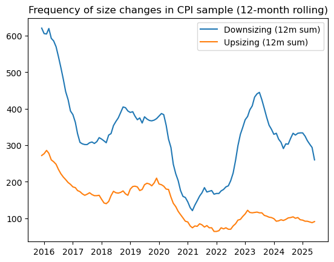

```
Could not find 'Food at home' in index_long['item'] — we’ll check item names.
```

```python
import matplotlib.pyplot as plt

# 1) Frequency rolling sums
plt.figure()
plt.plot(freq_std["date"], freq_std["down_roll"], label="Downsizing (12m sum)")
plt.plot(freq_std["date"], freq_std["up_roll"],   label="Upsizing (12m sum)")
plt.title("Frequency of size changes in CPI sample (12-month rolling)")
plt.legend()
plt.savefig(OUT_FIG / "fig2_frequency.png", bbox_inches="tight")
plt.show()

# 2) Food at home index
fa = index_long[index_long["item"].str.lower()=="food at home"].sort_values("date")
if not fa.empty:
    plt.figure()
    plt.plot(fa["date"], fa["value"], label="R-CPI-SC index (Dec 2014=100)")
    plt.title("Food at home (R-CPI-SC)")
    plt.legend()
    plt.savefig(OUT_FIG / "fig1_food_home_rcpi.png", bbox_inches="tight")
    plt.show()
else:
    print("Could not find 'Food at home' in index_long['item'] — we’ll check item names.")
```

### Quick Visual Checks

Before creating presentation ready visuals, it’s important to verify that the data was cleaned and merged correctly:

These quick plots act as our **diagnostic checks** and answer the questions:

- Do the series load without errors?
- Are the dates and values aligned properly?
- Do the overall trends look reasonable compared to expectations?

Once these checks are confirmed we can move onto the visual figures with clear titles, labels, and annotations people can easily understand.

```python
# What does the file actually call this item?
items = index_long["item"].dropna().astype(str).unique().tolist()

# Print a small sample first
print("Total unique items:", len(items))
print("First 20 items:\n", items[:20])

# Show anything that looks like food at home ignoring case/spaces
candidates = [i for i in items if "food" in i.lower() and "home" in i.lower()]
print("\nCandidates that contain 'food' and 'home':")
for c in candidates:
    print("-", repr(c))
```

```
Total unique items: 75
First 20 items:
 ['Food at home ', 'Flour and prepared flour mixes ', 'Breakfast cereal ', 'Rice, pasta, cornmeal ', 'Bread ', 'Fresh biscuits, rolls, muffins ', 'Cakes, cupcakes, and cookies ', 'Other bakery products ', 'Uncooked ground beef ', 'Uncooked beef roasts ', 'Uncooked beef steaks ', 'Uncooked other beef…

Candidates that contain 'food' and 'home':
- 'Food at home '
```

```python
# Create a clean item column with spaces collapsed and trimmed
index_long = index_long.copy()
index_long["item_clean"] = (
    index_long["item"]
    .astype(str)
    .str.replace(r"\s+", " ", regex=True)  # collapse multiple spaces
    .str.strip()                            # remove leading/trailing spaces
)

# show status current
print("Unique example names:", index_long["item_clean"].drop_duplicates().tolist()[:10])
```

```
Unique example names: ['Food at home', 'Flour and prepared flour mixes', 'Breakfast cereal', 'Rice, pasta, cornmeal', 'Bread', 'Fresh biscuits, rolls, muffins', 'Cakes, cupcakes, and cookies', 'Other bakery products', 'Uncooked ground beef', 'Uncooked beef roasts']
```

```python
fa = (index_long
      [index_long["item_clean"].str.lower().eq("food at home")]
      .sort_values("date"))

print("Rows found:", len(fa))
fa.head(3)
```

```
Rows found: 127
```

|  | item | series | date | value | item_clean |
| --- | --- | --- | --- | --- | --- |
| 0 | Food at home | SAF11 | 2014-12-01 | 100.000 | Food at home |
| 54 | Food at home | SAF11 | 2015-01-01 | 100.288 | Food at home |
| 108 | Food at home | SAF11 | 2015-02-01 | 100.184 | Food at home |

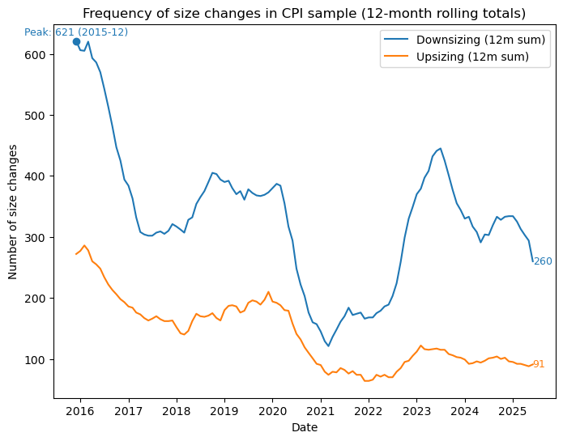

```
Saved to: /Users/hadilghazal/DataProject/outputs/figures/fig1_food_home_rcpi.png
```

```python
import matplotlib.pyplot as plt

plt.figure(figsize=(8,6))

# Plot the rolling sums
plt.plot(freq_std["date"], freq_std["down_roll"], label="Downsizing (12m sum)")
plt.plot(freq_std["date"], freq_std["up_roll"],   label="Upsizing (12m sum)")

# Titles and the labels
plt.title("Frequency of size changes in CPI sample (12-month rolling totals)")
plt.ylabel("Number of size changes")
plt.xlabel("Date")
plt.legend()

# Adding labels at the most recent point
latest_date = freq_std["date"].max()

down_latest = freq_std.loc[freq_std["date"] == latest_date, "down_roll"].values[0]
up_latest   = freq_std.loc[freq_std["date"] == latest_date, "up_roll"].values[0]

plt.text(latest_date, down_latest, f"{int(down_latest)}",
         va="center", ha="left", color="C0", fontsize=9)
plt.text(latest_date, up_latest, f"{int(up_latest)}",
         va="center", ha="left", color="C1", fontsize=9)

# --- Annotate peak downsizing ---
peak_idx = freq_std["down_roll"].idxmax()
peak_date = freq_std.loc[peak_idx, "date"]
peak_val  = freq_std.loc[peak_idx, "down_roll"]

plt.scatter(peak_date, peak_val, color="C0")
plt.text(peak_date, peak_val+10, f"Peak: {int(peak_val)} ({peak_date:%Y-%m})",
         ha="center", color="C0", fontsize=9)

# Save and  show result
plt.savefig(OUT_FIG / "fig2_frequency.png", bbox_inches="tight")
plt.show()


print("Saved to:", OUT_FIG / "fig1_food_home_rcpi.png")
```

## How Often Does Shrinkflation Happen?

This line chart shows 12-month rolling totals of the downsizing/shrinking (which is in blue) versus the upsizing (which is orange) events in the CPI sample.

This chart is the link between the two stories:

- The **R-CPI-SC charts** shows what prices looked like without shrinkflation,
- The **frequency chart** shows how often shrinkflation was happening,
- Together, they explain why shoppers felt a stronger pinch than prices alone can capture.

*Note:* These counts come from the CPI sample, not the entire marketplace . they are indicative not exhaustive.

## Which Categories Feel Shrinkflation the Most?

To highlight where the impact is strongest, we can compare the **cumulative price change since December 2019** across diffeent categories using the shrinkflation-adjusted index (R-CPI-SC)

- This tells us where prices rose the most without shrinkflation baked in.
- When combined with the frequency data, it helps reveal the aisles where shoppers felt a **double effect**: not only were prices climbing faster but packages were shrinking more often as well.

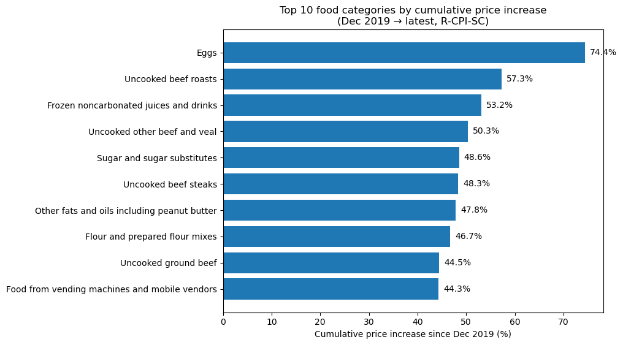

```python
# Take a Dec 2019 baseline
base = (index_long[index_long["date"] == "2019-12-01"]
        .rename(columns={"value":"base_value"})[["item_clean","series","base_value"]])

# Merge that into full data
merged = index_long.merge(base, on=["item_clean","series"], how="left")

# Compute the cumulative index since Dec 2019
merged["cum_index"] = 100 * merged["value"] / merged["base_value"]

# Take latest month available for each item
latest = (merged.sort_values("date")
          .groupby(["item_clean","series"], as_index=False)
          .tail(1))

# Sort by biggest cumulative increase
top = latest.sort_values("cum_index", ascending=False).head(10)

#plotting steps
import matplotlib.pyplot as plt

plt.figure(figsize=(8,6))
bars = plt.barh(top["item_clean"], top["cum_index"] - 100)
plt.gca().invert_yaxis()

plt.title("Top 10 food categories by cumulative price increase\n(Dec 2019 → latest, R-CPI-SC)")
plt.xlabel("Cumulative price increase since Dec 2019 (%)")

# --- Add labels on each bar ---
for bar in bars:
    width = bar.get_width()
    plt.text(
        width + 1,                 # x position (a little to the right of the bar)
        bar.get_y() + bar.get_height()/2,  # y position = middle of bar
        f"{width:.1f}%",           # format: 1 decimal + percent sign
        va="center"
    )

plt.savefig(OUT_FIG / "fig3_top_categories.png", bbox_inches="tight")
plt.show()
```

## Top Categories by Cumulative Price Increase (Dec 2019 to as of latest June 2025)

This bar chart shows the **total percent increase in prices since December 2019** - using the R-CPI-SC index (which removes the direct effect of size changes)

Together the two datasets suggest a **double impact**:

```python
DATA_PROC.mkdir(parents=True, exist_ok=True)
index_long.to_csv(DATA_PROC / "r_cpi_sc_long.csv", index=False)
freq_std.to_csv(DATA_PROC / "r_cpi_sc_frequency.csv", index=False)

print("Saved processed CSVs to:", DATA_PROC)
```

```
Saved processed CSVs to: /Users/hadilghazal/DataProject/data/processed
```

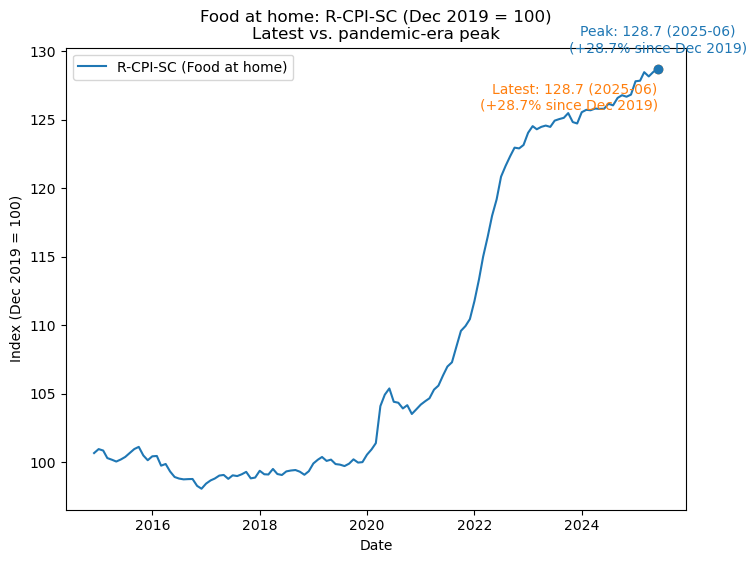

```
Saved: /Users/hadilghazal/DataProject/outputs/figures/fig1_food_home_rcpi_2019base.png
```

```python
import matplotlib.pyplot as plt
import pandas as pd

# 1) Get Food at home  and sort
fa = (index_long[index_long["item_clean"].str.lower().eq("food at home")]
      .sort_values("date")
      .copy())

if fa.empty:
    raise ValueError("Could not find 'Food at home' in index_long['item_clean'].")

# 2) Rebase to Dec 2019 = 100 to match your other chart
base_row = fa.loc[fa["date"] == pd.Timestamp("2019-12-01"), "value"]
if base_row.empty:
    raise ValueError("Dec 2019 not found in Food-at-home series. Check available dates.")
base_val = float(base_row.iloc[0])
fa["index_2019=100"] = 100 * fa["value"] / base_val

# 3) Identifying the latest and the peak points to annotate
latest_date = fa["date"].max()
latest_val  = float(fa.loc[fa["date"] == latest_date, "index_2019=100"].iloc[0])

# Peak here
fa_after_2020 = fa[fa["date"] >= "2020-01-01"]
peak_idx = fa_after_2020["index_2019=100"].idxmax()
peak_date = fa_after_2020.loc[peak_idx, "date"]
peak_val  = float(fa_after_2020.loc[peak_idx, "index_2019=100"])

# 4) Plotting
plt.figure(figsize=(8,6))
plt.plot(fa["date"], fa["index_2019=100"], label="R-CPI-SC (Food at home)")

plt.title("Food at home: R-CPI-SC (Dec 2019 = 100)\nLatest vs. pandemic-era peak")
plt.ylabel("Index (Dec 2019 = 100)")
plt.xlabel("Date")
plt.legend()

# 5) Add annotations
# the latest label (shift left and down slightly to avoid overlapping values with the peak)
plt.scatter(latest_date, latest_val, color="C1")
plt.text(latest_date, latest_val - 1,
         f"Latest: {latest_val:.1f} ({latest_date:%Y-%m})\n(+{latest_val-100:.1f}% since Dec 2019)",
         va="top", ha="right", color="C1")

# peak label (updated to be shift up slightly and avoid overlapping values)
plt.scatter(peak_date, peak_val, color="C0")
plt.text(peak_date, peak_val + 1,  # move label up a bit
         f"Peak: {peak_val:.1f} ({peak_date:%Y-%m})\n(+{peak_val-100:.1f}% since Dec 2019)",
         va="bottom", ha="center", color="C0")

# 6) Save
plt.savefig(OUT_FIG / "fig1_food_home_rcpi_2019base.png", bbox_inches="tight")
plt.show()

print("Saved:", OUT_FIG / "fig1_food_home_rcpi_2019base.png")
```

## Food at Home: Shrinkflation in Groceries and the Clear Change Since the Pandemic

This chart shows the **Research CPI without product size changes (R-CPI-SC)** for Food at home, rebased to **December 2019 = 100**.

This figure highlights the **felt experience of shrinkflation**: even if official inflation slows, elevated prices combined with frequent downsizing create lasting sticker shock for shoppers.